# Foundations of Data Science - Wrangling and Plotting

MB5370 R4MarineScience

Author

Kylar Duffy

## Overview

This workshop introduced the foundations of data wrangling and visualisation in R, with an emphasis on using tidyverse to explore, manipulate and summarise ecological datasets. Using the Palmer Penguins dataset, functions such as filter(), mutate(), group_by() and summarise() were used to investigate variation in penguin body mass across species and islands. Then ggplot2 and knitr were used to produce scientifically appropriate figures and formatted summary tables, including comparisons of standard deviation and standard error to explore how different measures of variability influence the presentation and interpretation of ecological data.

### Mean Penguin Body Mass by Species and Island

```r
penguins |>
  group_by(species, island) |>
  summarise(
    mean_body_mass = mean(body_mass_g, na.rm = TRUE),
    .groups = "drop"
  ) |>
  knitr::kable(
    caption = "Mean penguin body mass by species and island",
    col.names = c("Species", "Island", "Mean body mass (g)"),
    digits = 2
  )
```

Mean penguin body mass by species and island

| Species | Island | Mean body mass (g) |
| --- | --- | --- |
| Adelie | Biscoe | 3709.66 |
| Adelie | Dream | 3688.39 |
| Adelie | Torgersen | 3706.37 |
| Chinstrap | Dream | 3733.09 |
| Gentoo | Biscoe | 5076.02 |

### Body Mass Distribution

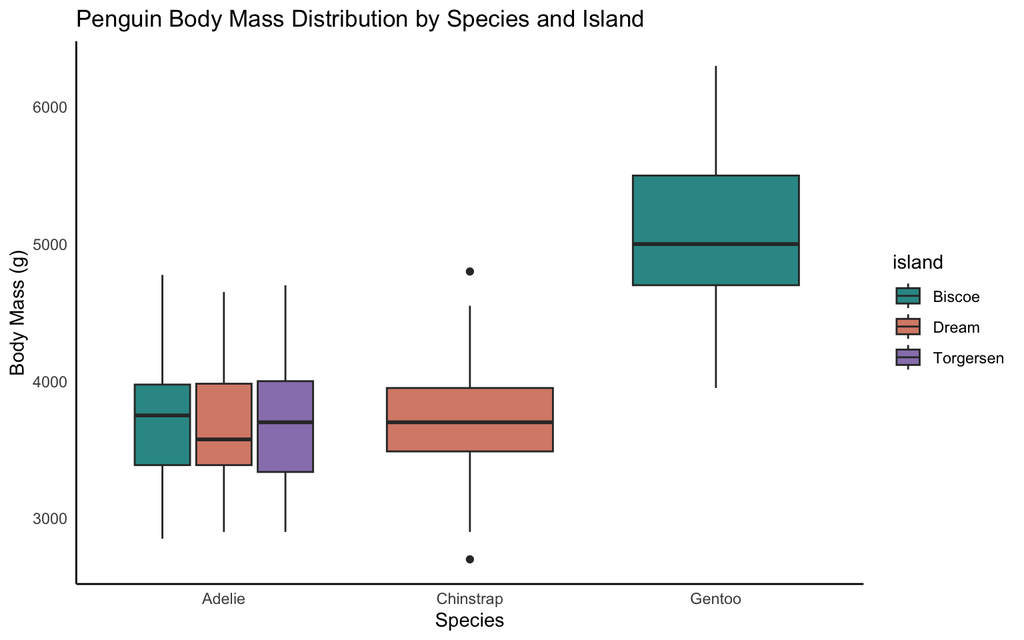

```r
penguins |>
  ggplot(aes(x = species,
             y = body_mass_g,
             fill = island)) +
  geom_boxplot() +
  scale_fill_manual(values = c("Dream" = "#D98B78", "Torgersen" = "#9982BA", "Biscoe" = "#319795")) +
  labs(
    title = "Penguin Body Mass Distribution by Species and Island",
    x = "Species",
    y = "Body Mass (g)") +
  theme_minimal() +
  theme(panel.grid.major = element_blank(),
        panel.grid.minor = element_blank(),
        axis.line = element_line(color = "black"))
```

## Comparing Variation and Uncertainty

### Standard Deviation

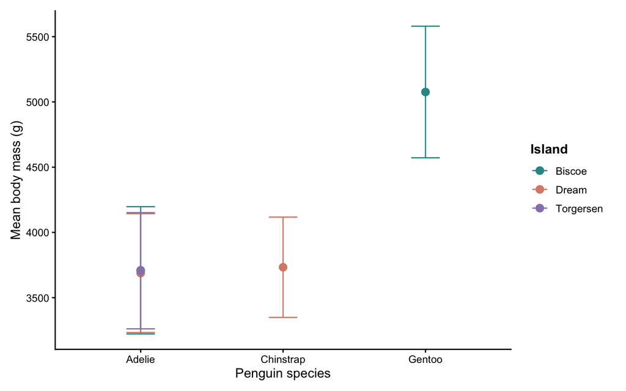

Mean body mass (g) of Adelie, Chinstrap and Gentoo penguins across three islands in the Palmer Archipelago. Points represent group means and error bars indicate ±1 standard deviation (SD).

```r
mass_compare_plot <- penguins |>
  group_by(species, island) |>
  summarise(
    mean_mass = mean(body_mass_g, na.rm = TRUE),
    sd_mass = sd(body_mass_g, na.rm = TRUE),
    n = n(),
    .groups = "drop"
  ) |>
  ggplot(aes(x = species, y = mean_mass, colour = island)) +
  geom_point(size = 3) +
  geom_errorbar(
    aes(ymin = mean_mass - sd_mass,
        ymax = mean_mass + sd_mass),
    width = 0.2
  ) +
  scale_colour_manual(
    values = c(
      "Biscoe" = "#319795",
      "Dream" = "#D98B78",
      "Torgersen" = "#9982BA"
    )
  ) +
  labs(
    x = "Penguin species",
    y = "Mean body mass (g)",
    colour = "Island"
  ) +
  theme_classic(base_size = 12) +
  theme(
    axis.text = element_text(colour = "black"),
    axis.title = element_text(size = 12),
    legend.position = "right",
    legend.title = element_text(face = "bold"),
    plot.margin = margin(10, 15, 10, 10)
  )

mass_compare_plot
```

### Standard Error

```r
mass_compare_plot2 <- penguins |>
  group_by(species, island) |>
  summarise(
    mean_mass = mean(body_mass_g, na.rm = TRUE),
    sd_mass = sd(body_mass_g, na.rm = TRUE),
    n = n(),
    .groups = "drop"
  ) |>
  mutate(
    se_mass = sd_mass / sqrt(n)
  )


knitr::kable(
  mass_compare_plot2,
  caption = "Summary of penguin body mass by species and island",
  digits = 2,
  col.names = c(
    "Species",
    "Island",
    "Mean mass (g)",
    "SD (g)",
    "Sample size",
    "SE (g)"
  )
)
```

Summary of penguin body mass by species and island

| Species | Island | Mean mass (g) | SD (g) | Sample size | SE (g) |
| --- | --- | --- | --- | --- | --- |
| Adelie | Biscoe | 3709.66 | 487.73 | 44 | 73.53 |
| Adelie | Dream | 3688.39 | 455.15 | 56 | 60.82 |
| Adelie | Torgersen | 3706.37 | 445.11 | 52 | 61.73 |
| Chinstrap | Dream | 3733.09 | 384.34 | 68 | 46.61 |
| Gentoo | Biscoe | 5076.02 | 504.12 | 124 | 45.27 |

#### Experiment with swapping standard deviation for standard error

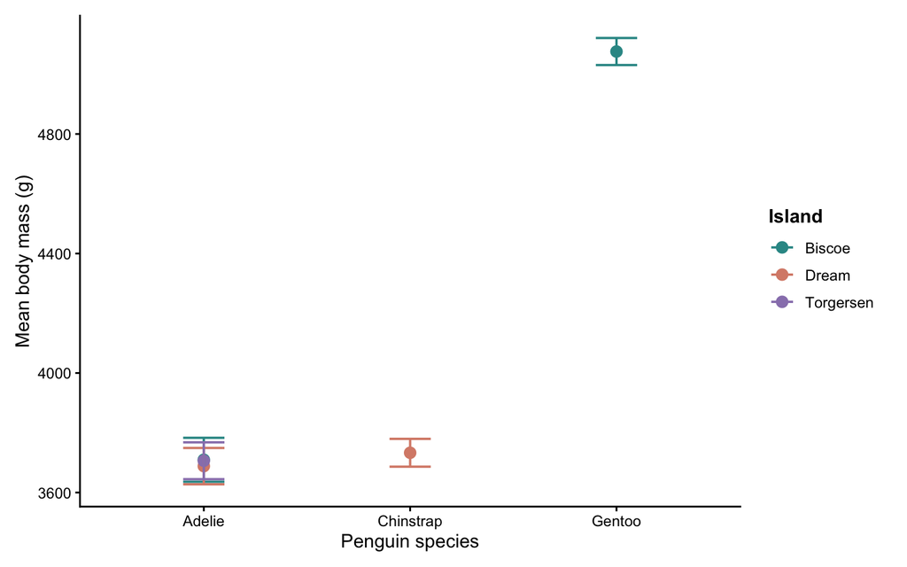

Mean body mass (g) of Adelie, Chinstrap and Gentoo penguins across three islands in the Palmer Archipelago. Points represent group means and error bars indicate ±1 standard error (SE).

```r
mass_compare_plotSE <- mass_compare_plot2 |>
  ggplot(aes(x = species, y = mean_mass, colour = island)) +
  geom_point(size = 3) +
  geom_errorbar(
    aes(
      ymin = mean_mass - se_mass,
      ymax = mean_mass + se_mass
    ),
    width = 0.2,
    linewidth = 0.7
  ) +
  scale_colour_manual(
    values = c(
      "Biscoe" = "#319795",
      "Dream" = "#D98B78",
      "Torgersen" = "#9982BA"
    )
  ) +
  labs(
    x = "Penguin species",
    y = "Mean body mass (g)",
    colour = "Island"
  ) +
  theme_classic(base_size = 12) +
  theme(
    axis.text = element_text(colour = "black"),
    axis.title = element_text(size = 12),
    legend.position = "right",
    legend.title = element_text(face = "bold"),
    plot.margin = margin(10, 15, 10, 10)
  )

mass_compare_plotSE
```

#### Ecological Interpretation

The Palmer Penguins dataset revealed clear differences in mean body mass between species. Gentoo penguins had the highest mean body mass (~ 5100g), while Adelie and Chinstrap penguins had similar but lower mean body masses (~ 3700g). Mean body mass was relatively consistent among Adelie penguins across Biscoe, Dream and Torgersen Islands suggesting limited variation in average body size. However, because Chinstrap and Gentoo penguins were only represented on Dream and Biscoe Islands, respectively, species and island effects cannot be fully determined.

Comparing standard deviation and standard error showed how different measures of variability influence the interpretation of ecological data. The wider SD error bars indicate substantial variation in body mass among individual penguins, whereas the narrower SE error bars indicate greater precision in the estimated mean body mass for each species/island group. Although these descriptive patterns suggest differences in body size between species, statistical testing would be required to determine whether the observed differences are statistically significant.

### Workshop Reflection

This workshop helped me develop a stronger understanding of the foundations of data wrangling and visualisation in R. Working through the exercises made me more familiar with the tidyverse workflow, particularly introducing me to using pipes (|>) to connect functions. I also developed a better understanding of how tibbles differ from traditional data frames, particularly in how they display data structures and variable types.

An important part of the learning process was recognising how missing values can affect calculations and understanding why functions such as mean() and sd() require na.rm = TRUE when working with incomplete datasets. Creating visualisations with ggplot2 also helped me understand how individual layers contribute to a figure and how different measures of variability influence the interpretation of ecological data.

I initially found troubleshooting console errors challenging, but using online resources and the built-in Help helped me understand what was causing them and how to resolve them. Working through these issues, made me realise that many errors were more straightforward to fix than I had expected. This helped build my confidence in debugging code independently and reinforced the importance of understanding how each function works rather than simply focusing on the final output.

Overall, this workshop highlighted the importance of combining technical programming skills with problem-solving and clear scientific communication to produce reproducible analyses.